# Precipitation Interpolation

Using the `macrosheds` package to interpolate rain gauge measurments to a watershed

Spencer Rhea, Weston Slaughter, Mike Vlah

This walkthrough is intended for someone with a basic understanding of hydrology who whats to calculate basin average precipitation from a few rain gauges in or near a watershed. We recommend looking at one of our other walkthroughs **(MacroSheds Discharge and Chemistry Data Retrieval and Flux Calculation )** to get an understanding of how to use the MacroSheds dataset in conjunction with the package.

For this walkthrough we will use the National Oceanic and Atmospheric Administration’s Global Historical Climate Network- Daily dataset, via the rnoaa package, to locate precipitation gauges in our area of interest, the Cache La Poudre watershed at Fort Collins, CO.

# Install and explore the `macrosheds` package

To use the `macrosheds` package, you must first **make sure you have the `macrosheds` package on your computer, built, and installed in R**. Currently, the package is only available via github. If you have not already, you can install the `macrosheds` package as follows:

```r
# install.packages('devtools') #you may need to install devtools too

devtools::install_github("https://github.com/MacroSHEDS/macrosheds")
```

Now, that we have the `macrosheds` package, we load it into our library, along with other packages we will be using in this walkthrough.

```r
library(rnoaa)
library(sf)
library(lubridate)
library(macrosheds)
library(ggplot2)
library(tidyverse)
```

# Locate and download NOAA data

This is a helper function used to search NOAA’s Global Historical Climate Network- Daily dataset for gauges near a location with the rnoaa package. You can skip over this part unless you’re interested in downloading other data from NOAA.

```r
search_noaa_stations <- function(lat, long, noaa_sites, buffer_km, start_year, end_year) {

    # Site = an sf object with a minimum of the columns: site_code and geometry
    # noaa_sites = an sf object with NOAA site info, made above
    # buffer_km = the maximum distance from a stream gauge that will be searched
    #     for NOAA site
    # start_year = numeric of when NOAA data should start (set same as stream start date)
    # end_year = numeric of when NOAA data should have data through (set same as stream end date)

    site <- tibble(lat = lat, long = long) %>%
        sf::st_as_sf(coords = c('long', 'lat'), crs = 4326)

    buffer_m <- buffer_km*1000
    site_buf <- site %>%
        st_buffer(buffer_m)

    near_noaa <- st_filter(noaa_station_sf, site_buf)


    near_noaa_time <- near_noaa %>%
        filter(first_year <= start_year,
               last_year >= end_year)

    if(nrow(near_noaa_time) == 0){
        print(paste0('No station was found within ', buffer_km, ' km of site: ', site$site_code))
        return(list(data = tibble(),
                    relation = tibble(site_code = site$site_code,
                                      NOAA_id = NA,
                                      distance_km = NA)))
    }


    near_noaa_time <- near_noaa_time %>%
        mutate(distance = as.numeric(st_distance(geometry, site$geometry)))

    return(near_noaa_time)
}

download_clean_noaa_data <- function(noaa_ids) {

    noaa_data <- rnoaa::ghcnd(stationid = noaa_ids)

    col_names <- names(noaa_data)

    col_names[5:128] <- paste0(substr(col_names[5:128], 0, 5), '_', substr(col_names[5:128], 6, 7))

    colnames(noaa_data) <- col_names

    noaa_data_clean <- noaa_data %>%
        filter(element %in% c('TMAX', 'TMIN', 'PRCP'))

    noaa_data_clean_VALUE <- noaa_data_clean %>%
        select(id, year, month, element, grep('VALUE', col_names[5:128], value = T)) %>%
        pivot_longer(cols = grep('VALUE', col_names[5:128], value = T), values_to = 'VALUE') %>%
        mutate(day = str_split_fixed(name, '_', n = Inf)[,2]) %>%
        select(-name)

    noaa_data_clean_MFLAG <- noaa_data_clean %>%
        select(id, year, month, element, grep('MFLAG', col_names[5:128], value = T)) %>%
        pivot_longer(cols = grep('MFLAG', col_names[5:128], value = T), values_to = 'MFLAG') %>%
        mutate(day = str_split_fixed(name, '_', n = Inf)[,2]) %>%
        select(-name)

    noaa_data_clean_QFLAG <- noaa_data_clean %>%
        select(id, year, month, element, grep('QFLAG', col_names[5:128], value = T)) %>%
        pivot_longer(cols = grep('QFLAG', col_names[5:128], value = T), values_to = 'QFLAG') %>%
        mutate(day = str_split_fixed(name, '_', n = Inf)[,2]) %>%
        select(-name)

    noaa_data_clean_SFLAG <- noaa_data_clean %>%
        select(id, year, month, element, grep('SFLAG', col_names[5:128], value = T)) %>%
        pivot_longer(cols = grep('SFLAG', col_names[5:128], value = T), values_to = 'SFLAG') %>%
        mutate(day = str_split_fixed(name, '_', n = Inf)[,2]) %>%
        select(-name)

    all_noaa <- full_join(noaa_data_clean_VALUE, noaa_data_clean_MFLAG, by = c('id', 'year', 'month', 'day', 'element')) %>%
        full_join(., noaa_data_clean_QFLAG, by = c('id', 'year', 'month', 'day', 'element')) %>%
        full_join(., noaa_data_clean_SFLAG, by = c('id', 'year', 'month', 'day', 'element')) %>%
        filter(!is.na(VALUE)) %>%
        mutate(date = lubridate::ymd(paste0(year, '-', month, '-', day))) %>%
        mutate(VALUE = VALUE/10) %>%
        select(NOAA_id = id, date, element, VALUE, MFLAG, QFLAG, SFLAG)

    return(all_noaa)
}
```

We need the file that has the location of all gauges in the NOAA database, so we’ll use the `rnoaa::ghcnd_stations` function to pull that data and convert it to an sf object. Then we can do geospatial filters on the data.

```r
noaa_station <- rnoaa::ghcnd_stations()
# Only want sites that have temperature measurements
noaa_station_all_vars <- noaa_station %>%
    filter(element %in% c('PRCP'))

# Conver to sf object
noaa_station_sf <- noaa_station %>%
    filter(id %in% !!unique(noaa_station_all_vars$id)) %>%
    distinct(id, .keep_all = T) %>%
    sf::st_as_sf(., coords = c('longitude', 'latitude'), crs = 4326)
```

Now we’ll search for stations 30km from the center of the Poudre watershed

```r
near_stations <- search_noaa_stations(lat = 40.694473, long = -105.499921,
                                      noaa_sites = noaa_station_sf, buffer_km = 30,
                                      start_year = 2000, 2018)
```

Next we’ll download the precipitation data for these stations. This function will download noaa precipitation (PRCP), daily maximum (TMAX), and daily minimum (TMIN) temperature. NOAA provides this data in units of tenths of mm and tenths of degrees. The function will convert these units to mm and degrees C

```r
noaa_precip_data <- download_clean_noaa_data(noaa_ids = near_stations$id)
```

Precipitation data needs to be in the MacroSheds format to use the `ms_calc_watershed_precip` function. This format is a table with the columns: site_code = code for gauge

datetime = datetime of the observation

var = variable observed

val = value of observation

ms_status = 0 to indicate no issue, 1 to indicate possible issue

ms_interp = 0 to indicate the value was measured, 1 to indicate the value is interpolated from surrounding values

val_err = uncertainty unknown with observation, can set to 0 is unknown

We will also remove gauges that have more than 10% of their record missing in 2014

```r
ms_noaa_precip_data <- noaa_precip_data %>%
    filter(element == 'PRCP') %>%
    select(site_code = NOAA_id,
           datetime = date,
           var = element,
           val = VALUE) %>%
    mutate(ms_status = 0,
           ms_interp = 0,
           val_err= 0)  %>%
    mutate(var = 'IS_precipitation') %>%
    filter(year(datetime) == 2014)

# Check to make sure the precipitation records are mostly complete for 2014
complete_records <- ms_noaa_precip_data %>%
    group_by(site_code) %>%
    summarise(n = n()) %>%
    # Filter out any sites with more than 10 % of the record missing
    filter(n >= 329) %>%
    pull(site_code)

ms_noaa_precip_data <- ms_noaa_precip_data %>%
    filter(site_code %in% !!complete_records)

gauges_with_data <- unique(ms_noaa_precip_data$site_code)
```

We also need an sf object in the MacroSheds format with the locations of precipitation gauges. Macrosheds format for geospatial data is an `sf` object with the columns: site_code = code for site

geometry = geospatial informaiton for shape/point

We can use the NOAA site data and convert it to MacroSheds format.

```r
ms_near_stations <- near_stations %>%
    select(site_code = id,
           geometry) %>%
    filter(site_code %in% !!gauges_with_data)
```

# Look at watershed of interest

The last piece we need is a watershed boundary. The Poudre watersheds is included in MacroSheds as an example but see the data documentation for how to retrieve a watersheds using nhdplusTools.

```r
?poudre_ws
```

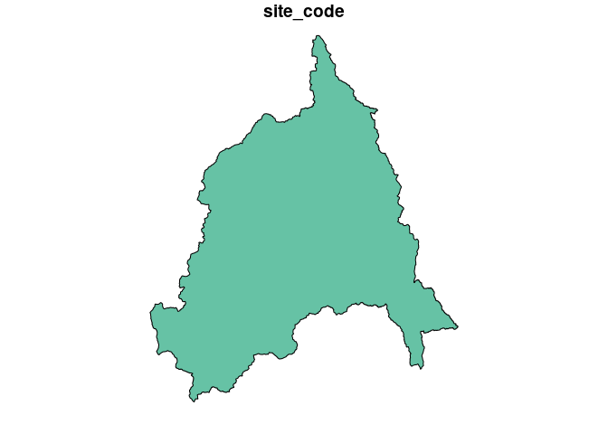

poudre_ws

# Calculate basin average precipitation

Now we have everything we need! Let’s put the data into the `ms_calc_watershed_precip` function! `ms_calc_watershed_precip` uses inverse distance weighting (IDW) over a raster grid to estimate a measurement of precipitation for every raster cell in a watershed. The function then takes an average over the whole watershed for every time interval (daily for this example).

`ms_calc_watershed_precip` also has a few arguments that are important to note. First, `parallel = TRUE` will run the function in parallel. Parallel processing is a way to leverage multiple cores on your computer to perform computationally intensive processing more quickly, by doing multiple processes at once. For more information on parallel computing in R take a look at this link: https://nceas.github.io/oss-lessons/parallel-computing-in-r/parallel-computing-in-r.html

The other important argument to pay attention to is `elevation_agnostic`. When `elevation_agnostic = TRUE`, `ms_calc_watershed_precip` will interpolate precipitation based purely on IDW. When `elevation_agnostic = FALSE`, the function uses a linear regression between precipitation at a gauge and elevation to predict precipitation in a digital elevation model (DEM) of the watershed. Then the function takes the average between the IDW raster and regression between precipitation and elevation to calculate basin average precipitation. This may be useful when calculating precipitation in a basin that has a significant relationship between elevation and precipitation.

```r
ms_calc_watershed_precip(precip = ms_noaa_precip_data,
                         ws_boundary = poudre_ws,
                         precip_gauge = ms_near_stations,
                         parallel = TRUE,
                         maxcores = Inf,
                         out_path = 'example',
                         elevation_agnostic = TRUE,
                         verbose = FALSE)
```

```
##
 Accessing raster elevation [-------------------------]   0%
 Accessing raster elevation [=====>-------------------]  25%
 Accessing raster elevation [===========>-------------]  50%
 Accessing raster elevation [==================>------]  75%
 Accessing raster elevation [=========================] 100%
## Mosaicing & Projecting
## Clipping DEM to bbox
```

Let’s look at the data!

```r
pourdre_precip <- feather::read_feather('example/precipitation__ms900/poudre_river.feather')
head(pourdre_precip)
```

```
## # A tibble: 6 × 7
##   datetime   site_code    var                val ms_status ms_interp val_err
##   <date>     <chr>        <chr>            <dbl>     <dbl>     <dbl>   <dbl>
## 1 2014-01-01 poudre_river IS_precipitation  2.06         0         0       0
## 2 2014-01-02 poudre_river IS_precipitation  1.13         0         0       0
## 3 2014-01-03 poudre_river IS_precipitation  1.11         0         0       0
## 4 2014-01-04 poudre_river IS_precipitation  6.07         0         0       0
## 5 2014-01-05 poudre_river IS_precipitation  2.78         0         0       0
## 6 2014-01-06 poudre_river IS_precipitation  1.91         0         0       0
```

[figure not shown]

```r
poudre_plot <- ggplot(pourdre_precip, aes(datetime, val)) +
    geom_line() +
    labs(x = 'Date', y = 'Precipitation (mm)')
```